# Entwicklung eines integrierten Wissensgraphen aus Ontologien für Biodiversität und Landwirtschaft

Masterarbeit — Master Data Science

Thorsten Hauke

thorsten.hauke@student.hs-anhalt.de

Hochschule Anhalt

5. Februar 2024

# Agenda

Grundlagen

Motivation und Ziele der Arbeit

Überblick zu Ontologien der Biodiversität und Landwirtschaft

Aufbau eines holistischen Wissensgraphen

Anwendung und Analyse

Fazit

# Grundlagen

## Grundlagen

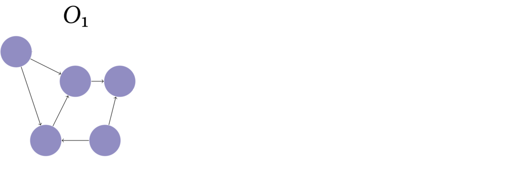

Abbildung 1a: Vereinfachte Ontologie

Ontologie

- Klassen/Begriffe: Knoten
- Beziehungen: Kanten
- Eigenschaften
- meist in RDF-Formaten serialisiert

Grundlagen

## Grundlagen

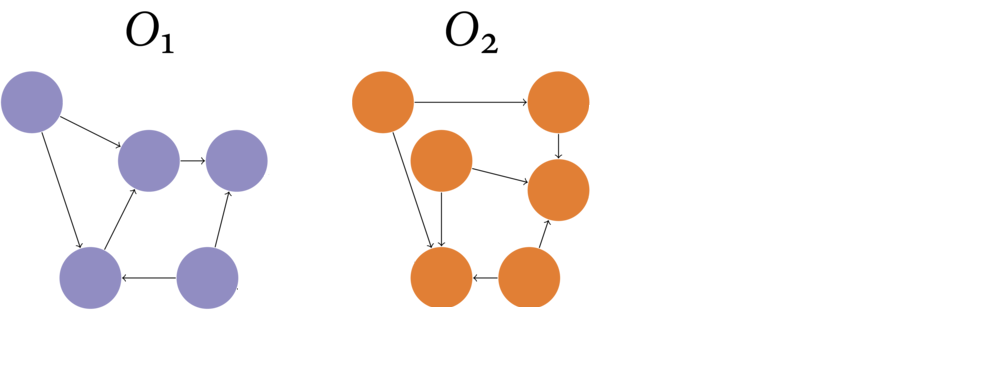

Abbildung 1b: Ontologie-Matching

Ontologie-Matching

Grundlagen

## Grundlagen

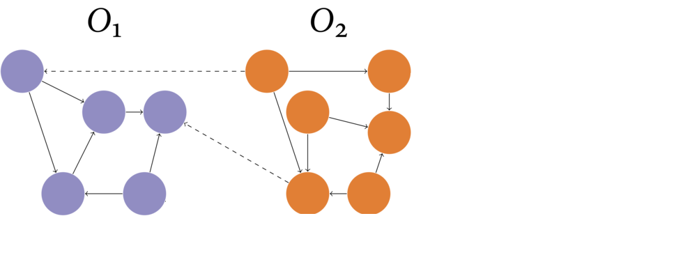

Abbildung 1b: Ontologie-Matching

Ontologie-Matching

- finden von Gleichheitsbeziehungen
- $k = 2$

Grundlagen

## Grundlagen

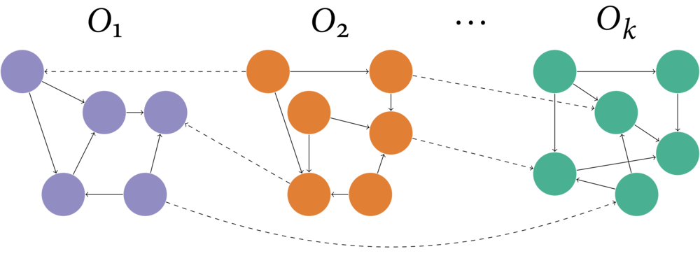

Abbildung 1c: holistisches Ontologie-Matching

Ontologie-Matching, holistisch

- finden von Gleichheitsbeziehungen
- $k > 2$

Grundlagen

# Motivation und Ziele der Arbeit

## Motivation Wissensgraph

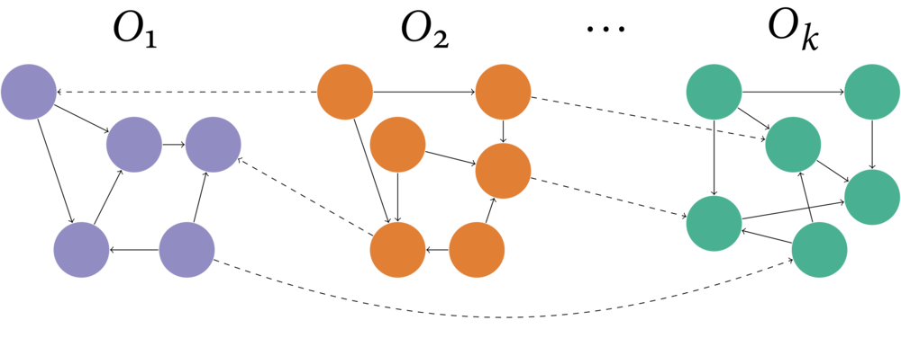

Abbildung 1d: Wissensgraph

- Wissensrepräsentation als Teilbereich der künstlichen Intelligenz
- Semantik
- Datenintegration
- Annotation
- Machine Learning

Motivation

## Ziele der Arbeit

1. Recherche zu Ontologien der Biodiversität und Landwirtschaft  
   ➔ Vergleichender Überblick
2. Aufbau eines integrierten Wissensgraphen
3. Anwendung und Analyse des integrierten Wissensgraphen

Ziele der Arbeit

# Überblick zu Ontologien der Biodiversität und Landwirtschaft

## Überblick zu Ontologien der Biodiversität und Landwirtschaft

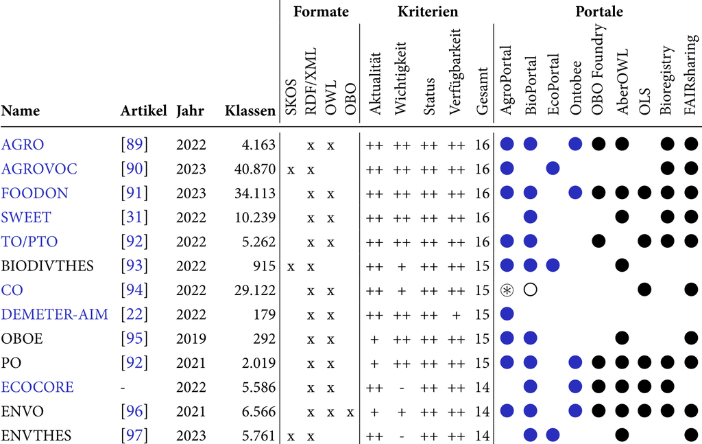

Überblick

## Überblick zu Ontologien der Biodiversität und Landwirtschaft

- 41 Ontologien

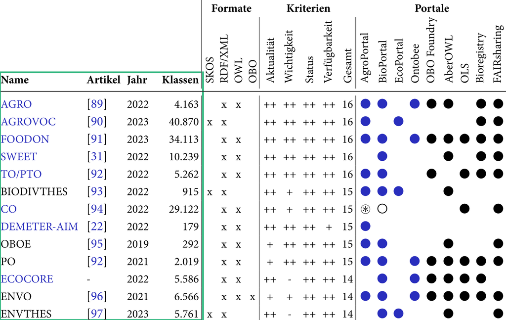

Überblick

## Überblick zu Ontologien der Biodiversität und Landwirtschaft

- 4 Formate

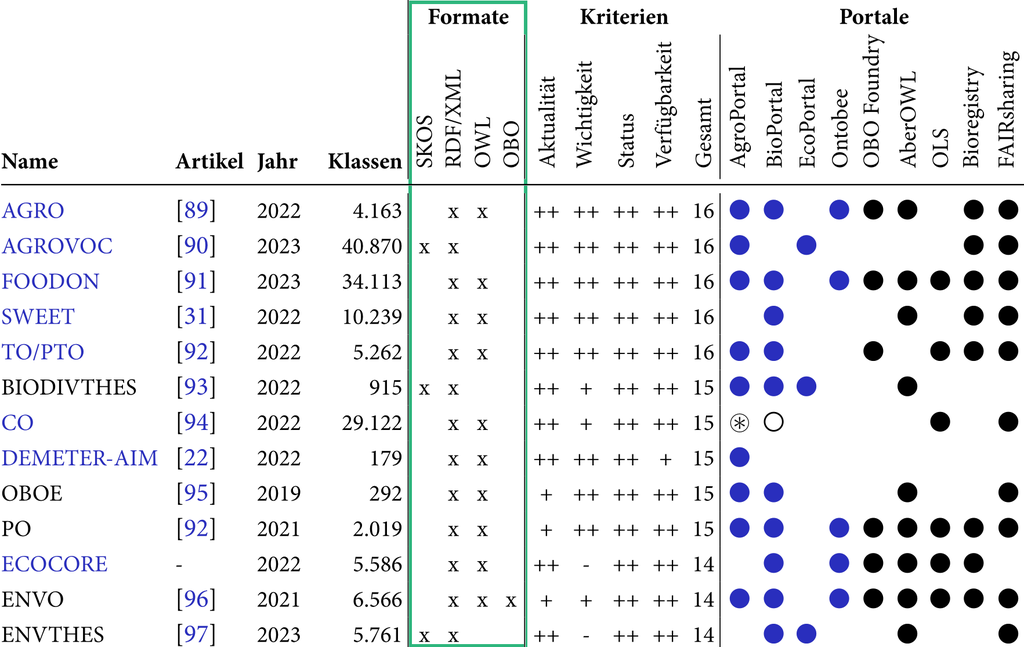

Überblick

## Überblick zu Ontologien der Biodiversität und Landwirtschaft

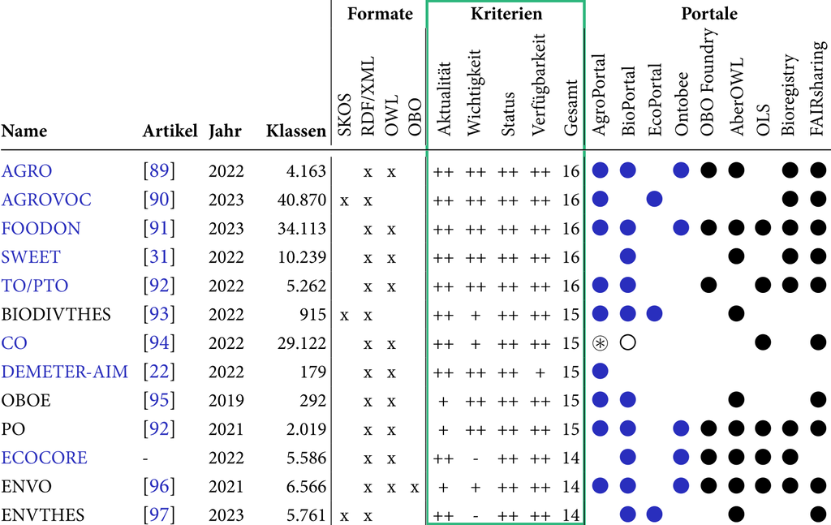

Überblick

## Überblick zu Ontologien der Biodiversität und Landwirtschaft

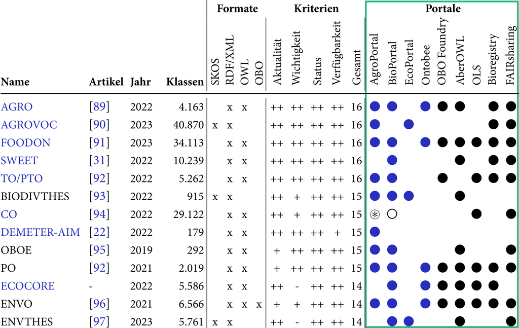

Überblick

# Aufbau eines holistischen Wissensgraphen

## Aufbau eines holistischen Wissensgraphen

Matching aller $k$ Ontologien zur Bestimmung von `sameAs`-Kanten

Integration der $k$ Ontologien mit den erzeugten Kanten und Import in die Graphdatenbank

Deskriptive sowie interaktive Analyse und Graphenanalyse wie Clustering

Visualisierung von Teilen des Wissensgraphen (interaktiv und statisch)

Konzept

## Aufbau eines holistischen Wissensgraphen

- Matching: AgreementMakerLight (Faria u. a. 2013)
- Graphdatenbank: Neo4j
- Neosemantics
- implementiert in Python 3

Konzept

## Aufbau eines holistischen Wissensgraphen

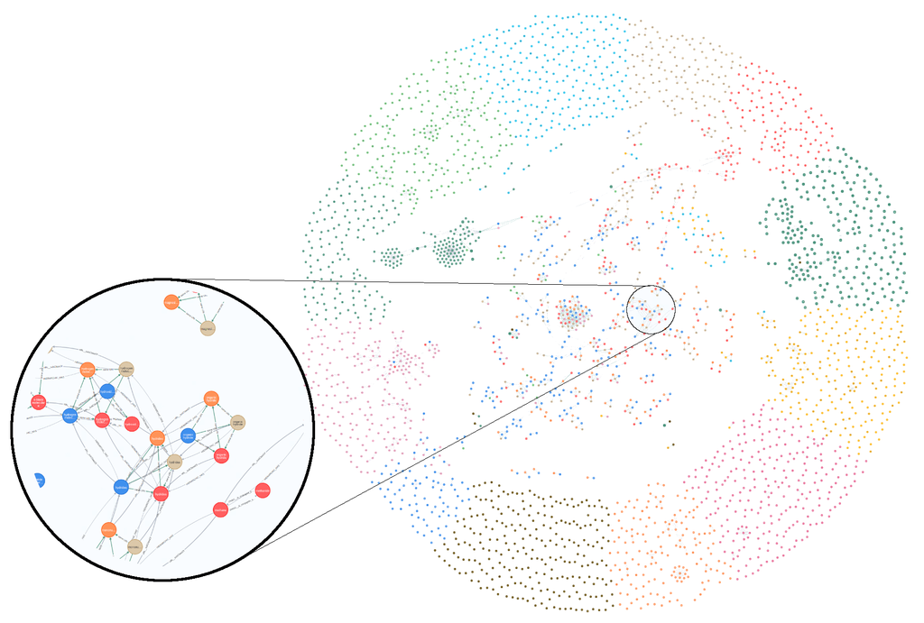

Abbildung 2: Ausschnitt aus 3000 Knoten

Konzept

### Eigenschaften des Wissensgraphen

- Erweiterbar
- Holistisch

Konzept

# Anwendung und Analyse

## Anwendung und Analyse

- ca 9,5 Mio Tripel ➔ Wissensgraph mit >100.000 Knoten
- Bereinigt und Vereinheitlicht

Anwendung und Analyse

## Anwendung und Analyse

```
MATCH p=()-[:rdfs__subClassOf*1..3]->()
RETURN p
```

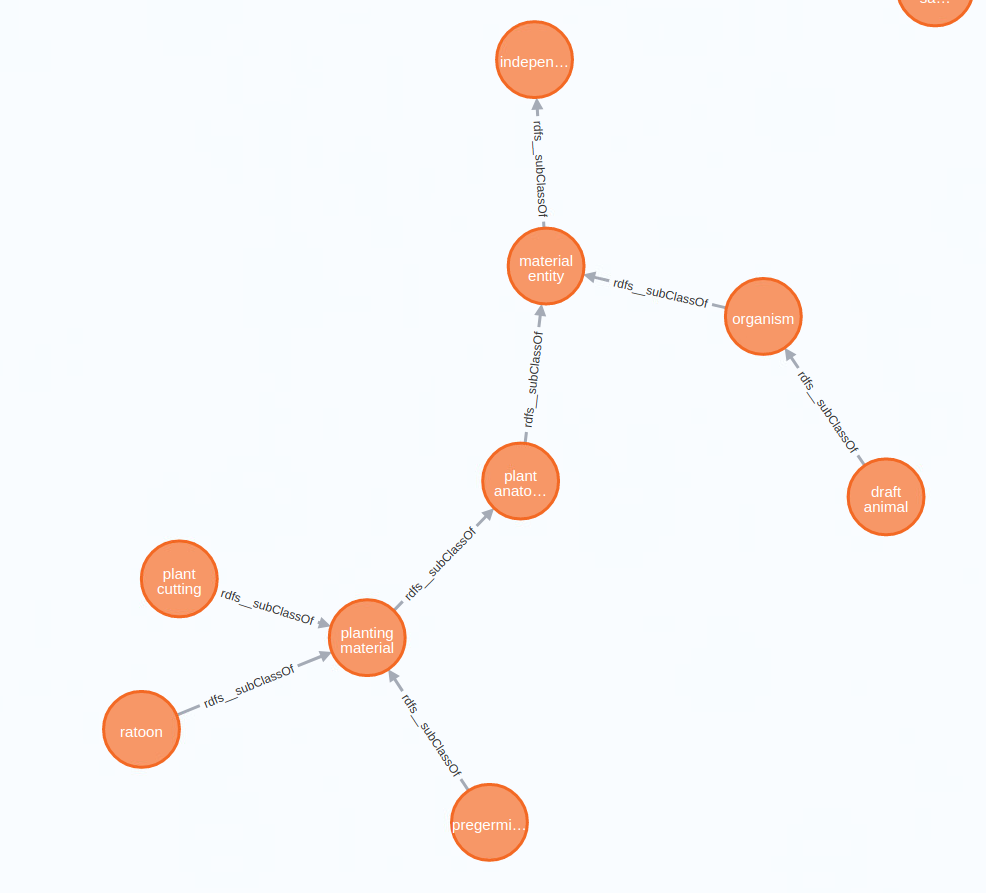

Abbildung 3: subClassOf Ergebniss

Anwendung und Analyse

## Anwendung und Analyse

[output not shown]

Anwendung und Analyse

# Fazit

## Fazit

- Beantwortung der drei Ziele im Kontext Biodiversität und Landwirtschaft
  1. Vergleichender Überblick
  2. Aufbau eines Wissensgraphen
  3. Anwendung und Analyse
- Limitationen
  - Ressourcen
  - Einfache Bereinigung
- Zukünftige Arbeit
  - Einbinden von Werkzeugen zur Annotation
  - Bereinigung in Zusammenarbeit mit Domänenfachleuten
  - Versionen (Graphtemporale Analysen)

Fazit

## Literatur

Faria, Daniel, Catia Pesquita, Emanuel Santos, Matteo Palmonari, Isabel F. Cruz, und Francisco M. Couto. 2013. „The AgreementMakerLight Ontology Matching System“. In *On the Move to Meaningful Internet Systems: OTM 2013 Conferences*, herausgegeben von Robert Meersman, Hervé Panetto, Tharam Dillon, Johann Eder, Zohra Bellahsene, Norbert Ritter, Pieter De Leenheer, und Deijing Dou, 527–41. Berlin, Heidelberg: Springer Berlin Heidelberg.

# Live-Demo

[figure not shown]